# Fish Data Analysis

Kurt Riggin

10/2/2024

## Question 1: How do the two species differ in average standard length by season?

First we can create a simple boxplot visual showing difference in Month, Species, and Standard Length with a cutoff line for Size Class:

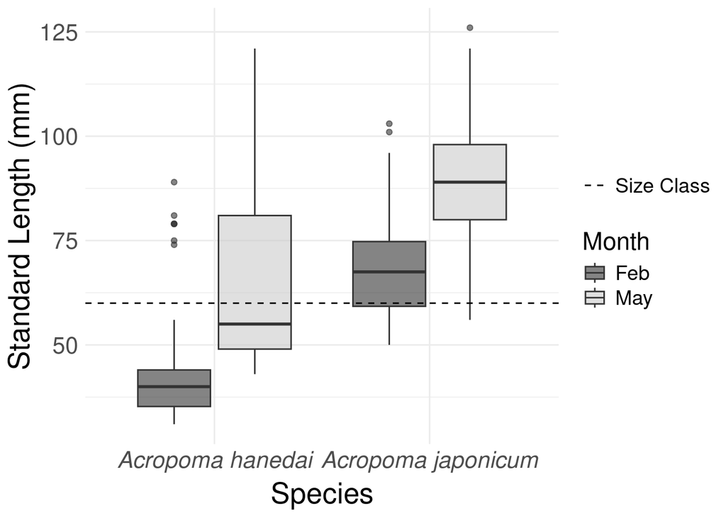

After log transforming our Standard Length values to normalize them, we can create various linear models based on Species and Month w/ interactions, either predicting standard length or size class and also including a random effect of the “Master Jar” each fish came from. Additionally, after computing AIC values for each model, we can determine the “best” one.

This leads us to our main linear model predicting log(Standard Length) with Species and Month, including interactions and random effect of master jars.

```
##  Family: gaussian  ( identity )
## Formula:          log(SL) ~ Species + Month + Species:Month + (1 | MJar)
## Data: fishdat2
##
##      AIC      BIC   logLik deviance df.resid
##      5.8     24.6      3.1     -6.2      164
##
## Random effects:
##
## Conditional model:
##  Groups   Name        Variance Std.Dev.
##  MJar     (Intercept) 0.01047  0.1023
##  Residual             0.05232  0.2287
## Number of obs: 170, groups:  MJar, 10
##
## Dispersion estimate for gaussian family (sigma^2): 0.0523
##
## Conditional model:
##                                    Estimate Std. Error z value Pr(>|z|)
## (Intercept)                         3.79998    0.08021   47.37  < 2e-16 ***
## SpeciesAcropoma japonicum           0.43370    0.13370    3.24 0.001179 **
## MonthMay                            0.33399    0.09970    3.35 0.000808 ***
## SpeciesAcropoma japonicum:MonthMay -0.06038    0.17259   -0.35 0.726466
## ---
## Signif. codes:  0 '***' 0.001 '**' 0.01 '*' 0.05 '.' 0.1 ' ' 1
```

We can see that fish in May are predicted to be significantly larger (p = 0.000808) as well as A. Japonicum (p = 0.001179).

## Question 2: Does a fish having any stomach content have bias in size, species or month?

We now can look at whether or not size, species, month and their interactions had an effect on if a fish had any stomach contents at all.

```r
#(1) For a generalized linear model predicting Content with Standard Length, Species and Month including interactions:
ContVarglmModel <- glmmTMB(Content ~ SL + Species + Month + SL:Species + SL:Month + Species:Month + SL:Species:Month + (1|MJar), data = fishdat2, family = binomial(link = 'logit'))
#summary(ContVarglmModel)
AIC(ContVarglmModel)
```

```
## [1] 241.0212
```

```r
#(2) For a generalized linear model predicting Content based on only intercept
ContglmModel <- glm(Content ~ 1, data = fishdat2, family = binomial(link = 'logit'))

AIC(ContglmModel)
```

```
## [1] 234.2705
```

After running several models to predict the presence of any stomach content in a fish based on size, species, and month, we find that there is no significant effect of any variable.

## Question 3: Now using our linear model to predict log(Standard length) from above, can we create 95% confidence intervals for the standard length of each combination of species and month?

General linear hypothesis tests of log(SL) of each combination of species and month as predicted from our model:

```
##
##   Simultaneous Tests for General Linear Hypotheses
##
## Fit: glmmTMB(formula = log(SL) ~ Species + Month + Species:Month +
##     (1 | MJar), data = fishdat2, family = gaussian(link = "identity"),
##     ziformula = ~0, dispformula = ~1)
##
## Linear Hypotheses:
##             Estimate Std. Error z value Pr(>|z|)
## hanfeb == 0  3.79998    0.08021   47.37   <2e-16 ***
## hanmay == 0  4.13397    0.05940   69.59   <2e-16 ***
## japfeb == 0  4.23369    0.10697   39.58   <2e-16 ***
## japmay == 0  4.50730    0.09162   49.19   <2e-16 ***
## ---
## Signif. codes:  0 '***' 0.001 '**' 0.01 '*' 0.05 '.' 0.1 ' ' 1
## (Adjusted p values reported -- none method)
```

Here are the exponentiated 95% CIs for Standard Length of each combination of species and month as predicted from our model.

```
##        Estimate      lwr       upr
## hanfeb 44.70046 38.19749  52.31052
## hanmay 62.42555 55.56468  70.13357
## japfeb 68.97101 55.92616  85.05857
## japmay 90.67669 75.77149 108.51393
```

## Question 4: Can we perform a PERMANOVA to determine signficant relationships with diet composition and ordinate the data using a Principal Coordinates Analysis?

First, predicting stomach composition by biovolume:

```
## Permutation test for adonis under reduced model
## Terms added sequentially (first to last)
## Permutation: free
## Number of permutations: 999
##
## adonis2(formula = BCmat ~ Species + Month + SClass + Species:Month + SClass:Species + SClass:Month + SClass:Species:Month, data = fishBCdat, by = "terms")
##                      Df SumOfSqs      R2       F Pr(>F)
## Species               1   1.3817 0.05753  5.5605  0.005 **
## Month                 1   0.2637 0.01098  1.0612  0.330
## SClass                1   2.3486 0.09779  9.4521  0.001 ***
## Species:Month         1   3.1162 0.12975 12.5414  0.001 ***
## Species:SClass        1   0.4372 0.01820  1.7595  0.158
## Month:SClass          1   0.1778 0.00740  0.7156  0.557
## Species:Month:SClass  1   0.1420 0.00591  0.5713  0.684
## Residual             65  16.1510 0.67245
## Total                72  24.0182 1.00000
## ---
## Signif. codes:  0 '***' 0.001 '**' 0.01 '*' 0.05 '.' 0.1 ' ' 1
```

Second, predicting stomach composition by frequency of occurrence (whether or not that type of content was present represented as either 0 or 1):

```
## Permutation test for adonis under reduced model
## Terms added sequentially (first to last)
## Permutation: free
## Number of permutations: 999
##
## adonis2(formula = BCmat2 ~ Species + Month + SClass + Species:Month + SClass:Species + SClass:Month + SClass:Species:Month, data = fishBCdat, by = "terms")
##                      Df SumOfSqs      R2       F Pr(>F)
## Species               1   1.1705 0.05595  5.8462  0.009 **
## Month                 1   0.2074 0.00991  1.0360  0.364
## SClass                1   2.8073 0.13418 14.0216  0.001 ***
## Species:Month         1   3.4138 0.16317 17.0510  0.001 ***
## Species:SClass        1   0.1294 0.00618  0.6462  0.519
## Month:SClass          1   0.0978 0.00467  0.4883  0.610
## Species:Month:SClass  1   0.0816 0.00390  0.4077  0.699
## Residual             65  13.0136 0.62203
## Total                72  20.9212 1.00000
## ---
## Signif. codes:  0 '***' 0.001 '**' 0.01 '*' 0.05 '.' 0.1 ' ' 1
```

From these calculated PermANOVAs, we can see that after predicting stomach composition by biovolume, ~18% of the variation is accounted for by species and interaction with month, even after accounting for the variation in size classes. For the PermANOVA predicting stomach composition by frequency of occurrence, this variation by species and interaction with month jumps up to ~22% after accounting for variation in size classes.

Now, after ordinating the data with a principal coordinates analysis, we see that because each collected fish tended to only have one kind of category of stomach content, our subsequent graphical representation is heavily drawn towards the axis, which will not be used in further analysis.

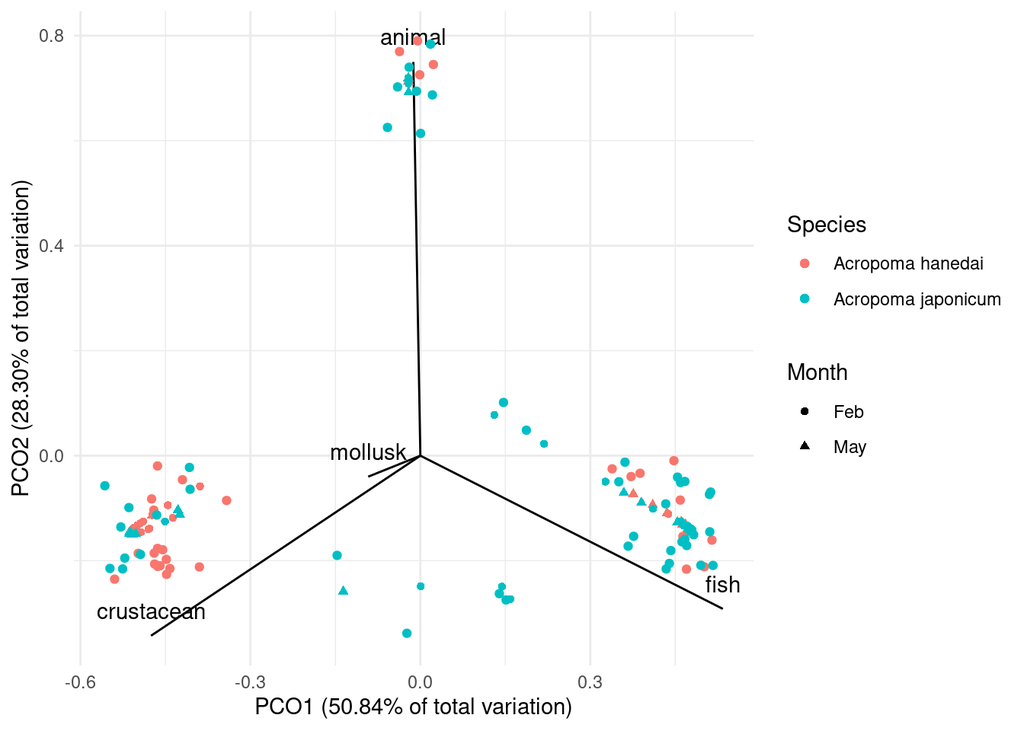

## Question 5: Can we create a visual representation of diet composition by both biovolume and frequency of occurance based on species month interactions?

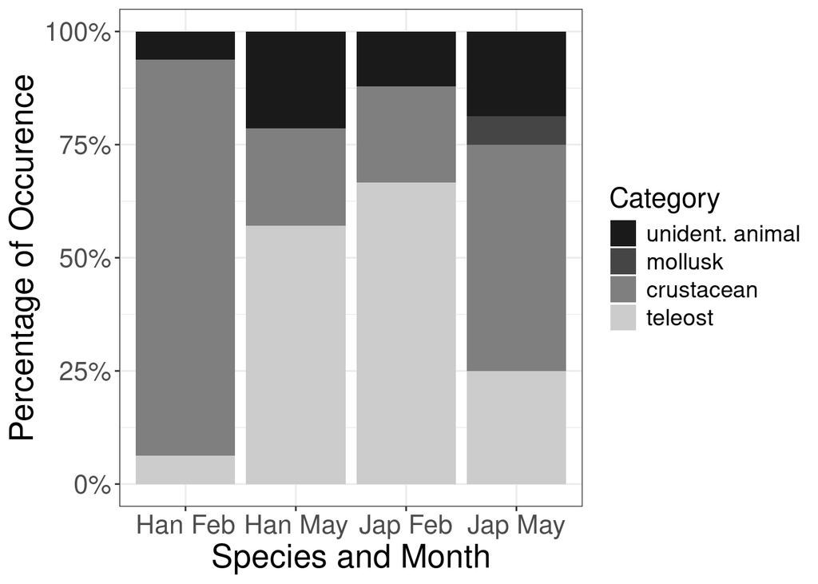

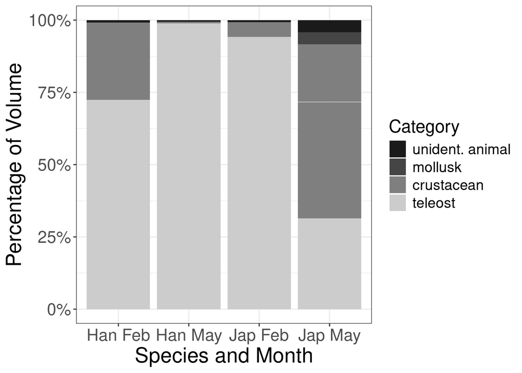

## Question 6: Can we predict frequnecy of occurance of specific types of stomach content (with focus on crustaceans and fish) using a generalized linear mixed model?

For the model predicting presence of crustaceans (using A. japonicum and May as basis):

```
##  Family: binomial  ( logit )
## Formula:          crustaceancount ~ Species + Month + Species:Month + SClass
## Data: fishdat2
##
##      AIC      BIC   logLik deviance df.resid
##    155.8    171.5    -72.9    145.8      165
##
##
## Conditional model:
##                                    Estimate Std. Error z value Pr(>|z|)
## (Intercept)                         -0.6699     0.3286  -2.038 0.041502 *
## SpeciesAcropoma japonicum           -0.3559     0.5956  -0.598 0.550131
## MonthMay                            -1.5430     0.6895  -2.238 0.025229 *
## SClass                              -1.3813     0.6052  -2.282 0.022464 *
## SpeciesAcropoma japonicum:MonthMay   3.1348     0.9317   3.364 0.000767 ***
## ---
## Signif. codes:  0 '***' 0.001 '**' 0.01 '*' 0.05 '.' 0.1 ' ' 1
```

We can see that this specific combination has a significant positive interaction (estimate = 3.1348) with odds of crustaceans (p = 0.000767). Still predicting the presence of crustaceans (using A. hanedai and May as basis instead):

```
##  Family: binomial  ( logit )
## Formula:          crustaceancount ~ Species + Month + Species:Month + SClass
## Data: fishdat2a
##
##      AIC      BIC   logLik deviance df.resid
##    155.8    171.5    -72.9    145.8      165
##
##
## Conditional model:
##                                  Estimate Std. Error z value Pr(>|z|)
## (Intercept)                       -1.0258     0.5250  -1.954 0.050727 .
## SpeciesAcropoma hanedai            0.3559     0.5956   0.598 0.550128
## MonthMay                           1.5918     0.6549   2.431 0.015074 *
## SClass                            -1.3813     0.6052  -2.282 0.022464 *
## SpeciesAcropoma hanedai:MonthMay  -3.1347     0.9317  -3.364 0.000767 ***
## ---
## Signif. codes:  0 '***' 0.001 '**' 0.01 '*' 0.05 '.' 0.1 ' ' 1
```

For A.hanedai and May predicting crustaceans, the significance does not change (p = 0.000767), but the direction of the interaction does (estimate = -3.1347).

For the model predicting presence of fish (using A. japonicum and May as basis):

```
##  Family: binomial  ( logit )
## Formula:          fishcount ~ Species + Month + Species:Month + SClass
## Data: fishdat2
##
##      AIC      BIC   logLik deviance df.resid
##    147.6    163.3    -68.8    137.6      165
##
##
## Conditional model:
##                                    Estimate Std. Error z value Pr(>|z|)
## (Intercept)                          -4.243      1.047  -4.051 5.09e-05 ***
## SpeciesAcropoma japonicum             2.648      1.082   2.446  0.01444 *
## MonthMay                              1.825      1.106   1.651  0.09884 .
## SClass                                1.559      0.558   2.794  0.00521 **
## SpeciesAcropoma japonicum:MonthMay   -3.411      1.260  -2.706  0.00681 **
## ---
## Signif. codes:  0 '***' 0.001 '**' 0.01 '*' 0.05 '.' 0.1 ' ' 1
```

We can see that this specific combination has a significant negative interaction (estimate = -3.411) with odds of fish (p = 0.00681). Still predicting the presence of fish (using A. hanedai and May as basis instead):

```
##  Family: binomial  ( logit )
## Formula:          fishcount ~ Species + Month + Species:Month + SClass
## Data: fishdat2a
##
##      AIC      BIC   logLik deviance df.resid
##    147.6    163.3    -68.8    137.6      165
##
##
## Conditional model:
##                                  Estimate Std. Error z value Pr(>|z|)
## (Intercept)                       -1.5951     0.5488  -2.907  0.00365 **
## SpeciesAcropoma hanedai           -2.6476     1.0824  -2.446  0.01444 *
## MonthMay                          -1.5853     0.6244  -2.539  0.01111 *
## SClass                             1.5590     0.5580   2.794  0.00521 **
## SpeciesAcropoma hanedai:MonthMay   3.4107     1.2604   2.706  0.00681 **
## ---
## Signif. codes:  0 '***' 0.001 '**' 0.01 '*' 0.05 '.' 0.1 ' ' 1
```

For A.hanedai and May predicting fish, the significance does not change (p = 0.00681), but the direction of the interaction does (estimate = 3.4107). We can see similar results if we switched months instead of species as well.

These models indicate that the interaction between species and month has a significant impact on whether or not a fish will have crustaceans or fish, and in specific with opposite effects.

## Additional Graphs/Information

Table of confidence intervals of proportion for both biovolume and frequency

For Frequency:

Proportion of Prescence Confidence Intervals

Analysis for Crustaceans and Fish

| Species and Month | Crustacean Count Estimate | Crustacean Count CI Lower | Crustacean Count CI Upper | Fish Count Estimate | Fish Count CI Lower | Fish Count CI Upper |
| --- | --- | --- | --- | --- | --- | --- |
| Acropoma hanedai_Feb | 0.30435 | 0.18198 | 0.45923 | 0.02174 | 0.00114 | 0.12970 |
| Acropoma hanedai_May | 0.06667 | 0.01738 | 0.19311 | 0.17778 | 0.08513 | 0.32583 |
| Acropoma japonicum_Feb | 0.12963 | 0.05802 | 0.25517 | 0.40741 | 0.27858 | 0.54937 |
| Acropoma japonicum_May | 0.32000 | 0.15729 | 0.53550 | 0.16000 | 0.05254 | 0.36917 |

For Biovolume:

Biovolume Confidence Intervals

Analysis for Crustaceans and Fish

| Species and Month | Crustacean Volume Estimate | Crustacean Volume CI Lower | Crustacean Volume CI Upper | Fish Volume Estimate | Fish Volume CI Lower | Fish Volume CI Upper |
| --- | --- | --- | --- | --- | --- | --- |
| Acropoma hanedai_Feb | 4.53261 | 1.10666 | 7.95856 | 12.26087 | −12.43379 | 36.95553 |
| Acropoma hanedai_May | 0.51111 | −0.13776 | 1.15998 | 77.90000 | 2.49763 | 153.30237 |
| Acropoma japonicum_Feb | 3.38896 | −0.14741 | 6.92534 | 62.38889 | 33.77480 | 91.00298 |
| Acropoma japonicum_May | 6.88000 | 0.72589 | 13.03411 | 3.60000 | −0.81372 | 8.01372 |